title: “CS 378 Data Science: An Analysis of Natural Disasters”

output: html_document

## What is a Natural Disaster?

It is a situation or event, which overwhelms local capacity, necessitating a request to national or international level for external assistance (definition considered in EM-DAT).

### Data Set and Sources

Our analysis relied on data from EM-DAT, the World Bank, the Advanced National Seismic System (ANSS), Global Risk Data Platform, and the World Data Service:

#### [**EM-DAT**](http://www.emdat.be/database)

EM-DAT is an international disaster database founded by the Centre for Research on the Epidemiology of Disasters (CRED). The EM-DAT database provided information from 1960-2014 such as:

- Disaster Type- Earthquakes, Storms, etc.
- Number Injured- Number of people reported injured in the disaster event.
- Number of Deaths- Number of people reported dead in the disaster event .
- Number left Homeless- Number of people reported homeless.
- Number Affected- Number - People requiring immediate assistance during a period of emergency, i.e. requiring basic survival needs such as food, water, shelter, sanitation and immediate medical assistance. Appearance of a significant number of cases of an infectious disease introduced in a region or a population that is usually free from that disease.
- Total Damage (Estimated) - Estimated loss caused by the disaster in US dollars.

#### [**World Bank**](http://databank.worldbank.org/data/home.aspx)

The World Bank is a United Nations international financial institution that provides loans to developing countries for capital programs. We enriched our dataset by incorporating country indicators from 1960-2014:

- GDP (in US dollars)
- Population
- Income Group (Gross National Income per Capita)
- Many others…

#### [**ANSS (Advanced National Seismic System) Global Earthquake Catalog**](http://ncedc.org/anss/catalog-search.html)

- ANSS is hosted by the Northern California Earthquake Data Center. The mission of ANSS is to provide accurate and timely data and information for seismic events, including their effects on buildings and structures.
- This dataset provided Global earthquake records from the last 50 years (since 2014) (~570,000 rows)
- Search parameters used:
  - catalog = ANSS
  - start_time = 1964/01/01,00:00:00
  - end_time = 2014/09/12,22:13:44
    - covers the last 50 years, anything larger would have been unmanageable/unrealistic at this point due to accuracy of data measurements
  - minimum_magnitude = 3.0
    - 3.0 was chosen as a minimum because that is generally the minimum threshold for people to notice an earthquake
  - maximum_magnitude = 10
  - event_type = E

#### [**Global Risk Data Platform: Earthquakes - Risk, Annual Average Losses**](http://preview.grid.unep.ch/index.php?preview=data&events=earthquakes&evcat=8&lang=eng)

- The Global Risk Data Platform is created and hosted by UNEP/GRID-Geneva and supported by UNISDR. The Global Risk Data Platform allows the visualisation of data on natural hazards, exposure (both human and economical), and risk.
- This dataset provided average annual losses from earthquakes (~ 200 rows after excluding those with missing data)

#### [**National Geophysical Data Center / World Data Service (NGDC/WDS): Significant Volcanic Eruptions Database**](http://www.ngdc.noaa.gov/nndc/servlet/ShowDatasets?dataset=102557&search_look=50&display_look=50)

- World Data Service is hosted by the National Geophysical Data Center of the National Oceanic and Atmospheric Administration.
- Search parameters were all left blank (so we used the entire data set, unfiltered)
- This dataset provides significant volcanic eruptions data (~650 rows)
  - includes eruptions over a long period of time (thousands of years) but predominantly contains information from the 1900s.

#### [**National Geophysical Data Center / World Data Service (NGDC/WDS): Global Historical Tsunami Database**](http://www.ngdc.noaa.gov/nndc/struts/form?t=101650&s=70&d=7)

- Hosted by the National Geophysical Data Center of the National Oceanic and Atmospheric Administration.
- This dataset provides Global tsunami source data (~2,500 rows) and Global tsunami runup data (~25,000 rows)
  - includes tsunamis from approximately the last two thousand years, but mostly from the last few hundred years.
- search parameters were all left blank (again using the entire data set, unfiltered)
- the url above links to the ‘event’ information, you can get to the ‘runup’ information [**here**](http://www.ngdc.noaa.gov/nndc/struts/form?t=101650&s=167&d=166)

## Geospatial Analysis

Our initial analysis used the following services ANSS, Global Risk Data Platform, and World Data Service to analyze specific natural disasters to get a sense of “what was interesting”:

- Earthquakes
- Tsunamis
- Volcanic Eruptions

Most of the work was exploratory. This analysis used RStudio to generate the results and process the data. Nothing of interest was really found but we learned a lot about R, RStudio, and Shiny. We also learned about the general workflow of obtaining the data, cleaning the data, filtering and applying transforms to see if the data revealed anything interesting.

### Results

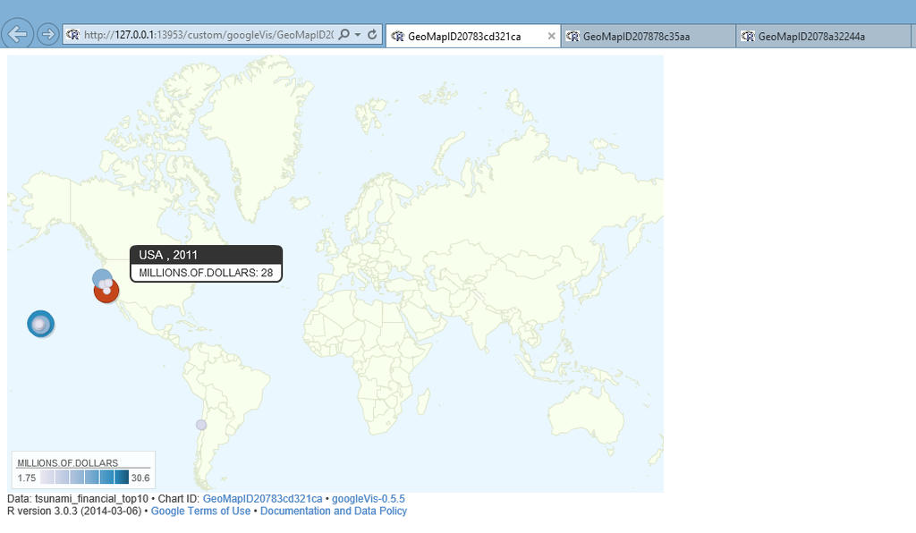

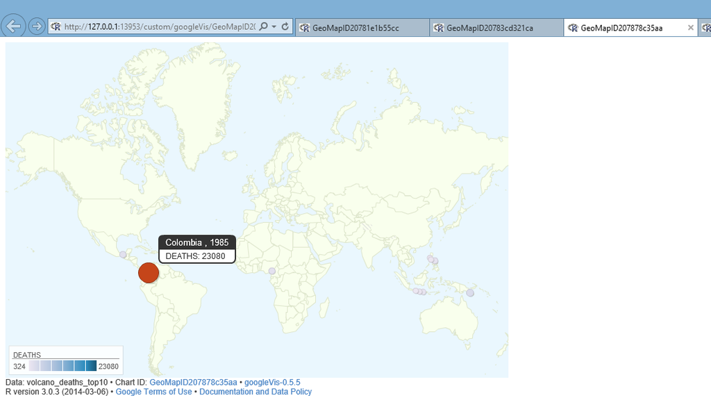

[figure not shown]

###Shiny App

The Shiny App interface:

[figure not shown]

## Natural Disasters: A Regional and Economic Perspective

Our more recent analysis considered the impact of natural disasters on countries internationally. This analysis used the EM-DAT and WorldBank data sets exclusively.

This analysis used the unsupervised algorithms Clustering and Anomaly Detection from Oracle Data Miner:

### Rare Disasters

Anomalous records in our data have the following disaster type:

- epidemics
- volcanic eruptions
- insect infestations
- mass movement (dry/wet)
- droughts

### Disaster Trends

The Occurrence measures how many times the disaster of that type occurred in a certain country for that year.

Out of all the disaster types high income countries seem to deal with frequent storms.

Disaster occurrences seem to be on the rise except for epidemics, insect infestation, mass movement (dry/wet), volcanoes, and wildfires.

### Measuring Disaster Significance

We chose to measure a natural disasters impact relative to a country in terms of two measures to more accurately assess the damage done by the disaster to the country.

- Demographic Damage Ratio=(#Affected + #Injured +#Deaths + #Homeless)/Population of Country
- Damage GDP Ratio= Total Damage /GDP of country

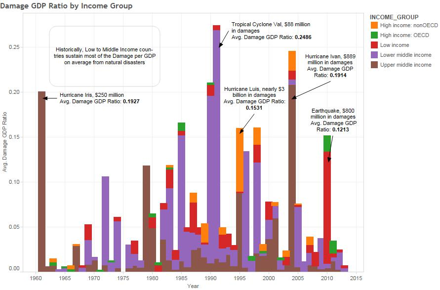

This is a bar chart plotting the average Damage GDP Ratio per year for all countries.

Each bar is broken into income groups of the countries contributing to this average.

Historically, High income countries (Orange and Green) do not contribute to the average Damage GDP Ratio as much as Low to Middle income countries.

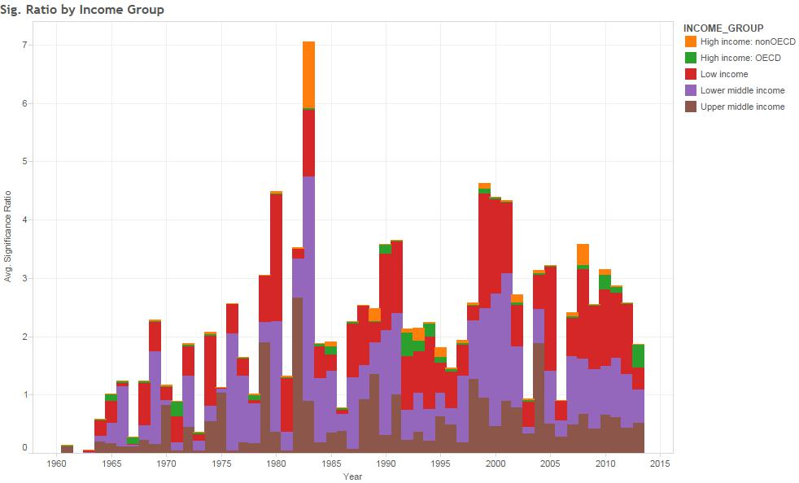

2)This bar chart depicts similar information to the previous one except the average Demographic Damage Ratio is calculated for each year.

Historically, High income countries do not sustain as much demographic damage than low to middle income countries.

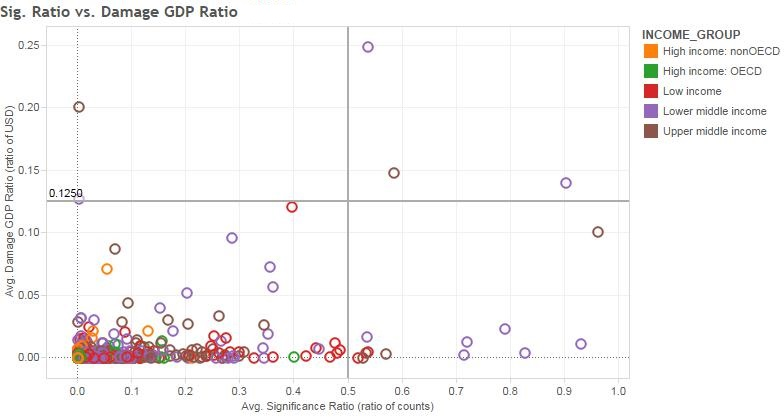

3)This scatterplot shows which disasters contributed most to the average Demographic Damage Ratio and the average Damage GDP Ratio (the averages were calculated across all years). It sums up the previous two bar charts by removing the Year axis and considering how much each country, color coded by its income group, contributed to each of the Average Damage GDP ratio and the Demographic Damage Ratio.

The outliers in the 1st,2nd, and 4th quadrants are lower to upper middle income countries. This plot reveals the outliers contributing disproportionately to the overall Averages of Demographic Damage and Damage GDP Ratios.

High income countries suffer less economic and demographic damage among natural disasters according to our data. Surprisingly, Low Income countries mostly lie in the third quadrant.

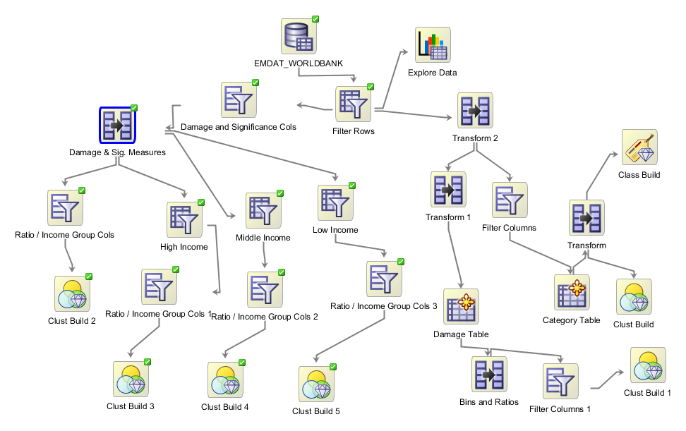

We used the K-Means algorithm and saw that the decision tree it produced generally grouped lower income countries into clusters with high demographic damage ratios and high damage gdp ratios. This led us to consider the scatterplot above. Then, we wondered if time played a role to see if these clusterings generally held. This led to two the bar charts above.

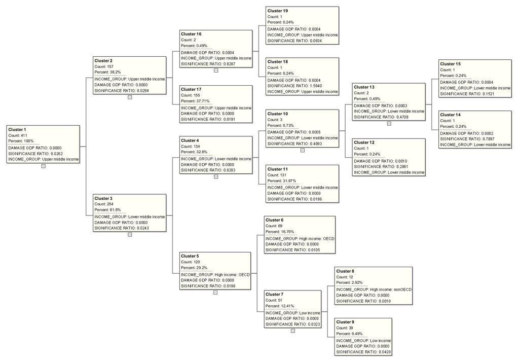

What we found: Low to middle Income countries contribute disproportionately more to the average of the demographic damage ratio and the damage gdp ratio.